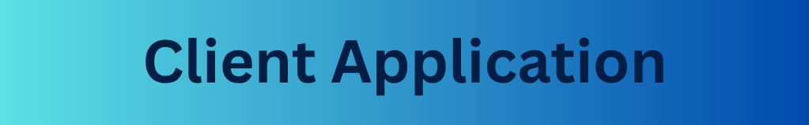

# Client A Case Study

A past client only referred to as Company A will be used as a case study on how the EU Omnibus package may effect current and future clients. The Canadian Aerospace company does not fall within the scope of the Carbon Border Adjustment Mechanism(CBAM) due to industry scope, either in its original form or proposed changes, and will therefore be excluded from its application.

## Published Company Statistics in 2024

| Company Overview |
| --- |
| Number of Employees: 3,700 |
| Net Turnover: €870.8 Million |
| EU Net Turnover: €300 Million |
| Total Assets: €500 Million |

*All monetary values were converted from U.S. dollars to euros using the 2024 average exchange rate of 0.924 (IRS, 2024) and then slightly altered for anonymity.

## Application of Case Study to the “Stop the Clock” Proposal:

Approved Changes to the CSRD:

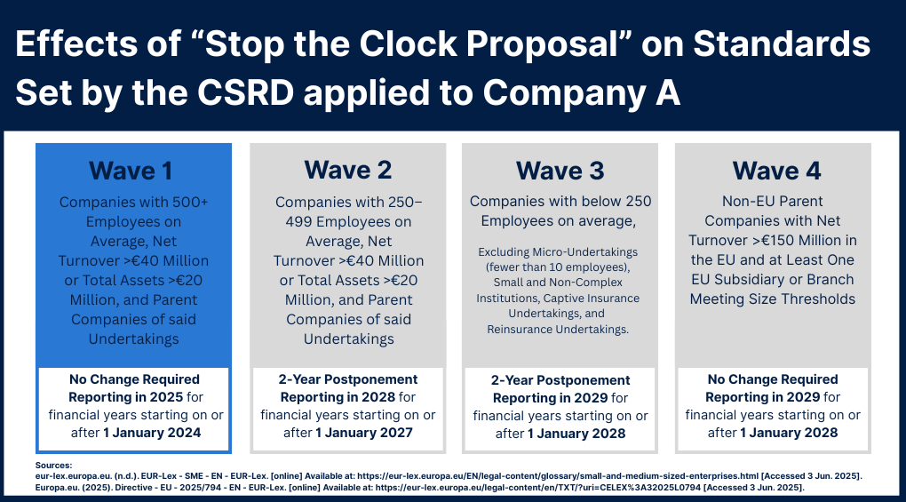

Company A is classified as a Wave 1 company, as it significantly exceeds both thresholds: employing over 500 people and reporting a net turnover of more than €40 million. As the company is classified as Wave 1, it is not affected by the proposal and is still required to report in 2025 for financial years beginning on or after January 1, 2024.

Approved Changes to the CSDDD:

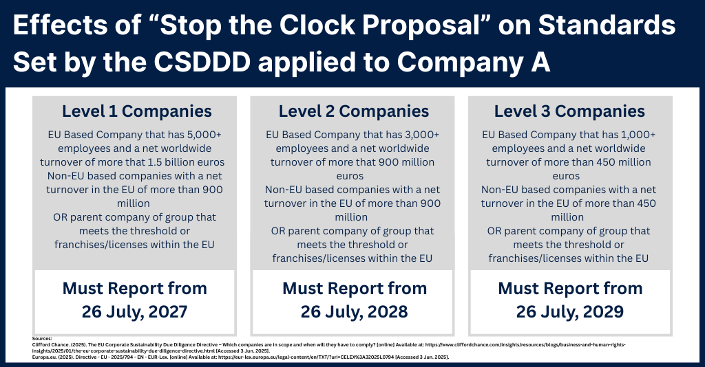

Company A does not meet the thresholds required for non-EU based companies to report under the CSDDD.

## Application of Case Study to Proposed Changes:

Proposed Changes to the CSRD:

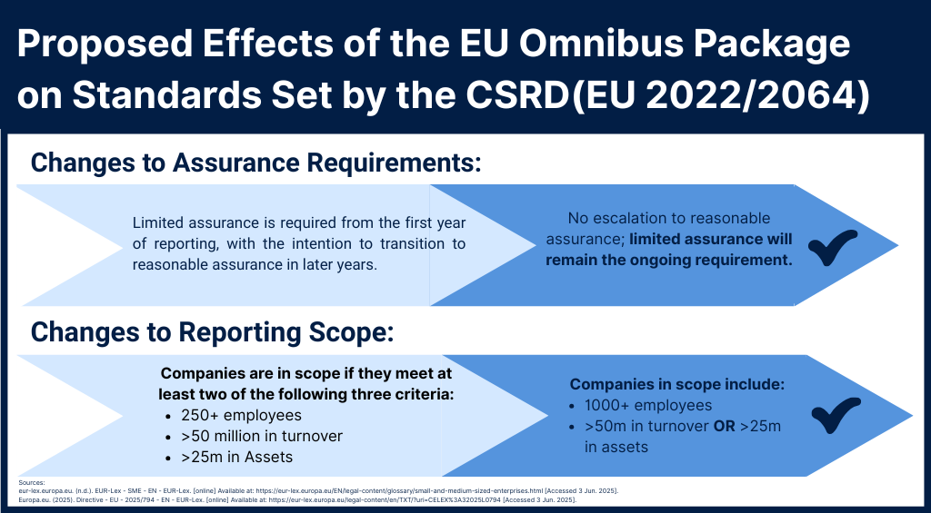

As Company A is a Wave 1 company under the CSRD and already required to report, it will not experience any changes to the reporting content or timeline. The only change is confirmation that assurance requirements will not be increase to reasonable assurance.

## Changes to EU Taxonomy:

Company A qualifies as a CSRD reporter. However, since it does not meet the thresholds set out in the CSDDD, it is not subject to the EU Taxonomy sustainability reporting requirements. However, it can choose to opt-in to taxonomy reporting. If Company A chooses not to claim any of its economic activities as environmentally sustainable under the EU Taxonomy, it is not required to report taxonomy KPIs. However, in doing so, it forfeits the ability to present itself as environmentally sustainable under the Taxonomy framework.

If the company opts to report under the EU Taxonomy, they will need to provide data on company turnover, Since we do not currently have access to these figures, [a recommended tool](https://ec.europa.eu/sustainable-finance-taxonomy/wizard), either for the company’s own use or to assist in estimating the share of funds aligned with the EU Taxonomy, is provided below:

[interactive chart not shown]